# Campaign Marketing Analysis

Alan Morales

2023-09-07

# 1 Intro

The goal of this project is to evaluate and understand the performance from a marketing campaign. Key performance indicators are used to evaluate the performance of the campaigns as well as understanding segments of the customer base. Income, amount spent on certain items, education level, relationship status, and children presence are some of the key indicators that will be used to gain insight into the campaign.

# 2 Data Description

2205 Observations/Rows and 53 Features/Variables/Columns total.

There are no missing values as the data set was curated and cleaned prior.

Three variables were removed due to the lack of relevance to the project.

**People**

- Income: Customer’s yearly household income
- Kidhome: Number of children in customer’s household
- Teenhome: Number of teenagers in customer’s household
- Recency: Number of days since customer’s last purchase
- Age: Customers age
- Customer_Days: Days since customer’s enrollment with the company
- TOT_Children: Total number of children and teens
- ChildrenBV: 1 if there are kids/teens, 0 otherwise
- Children: “Has Children” or “No Children”

**Products**

Depending if there is enough variability or need, this may be broken down into the last two variables of this list.

- MntWines: Amount spent on wine in last 2 years
- MntFruits: Amount spent on fruits in last 2 years
- MntMeatProducts: Amount spent on meat in last 2 years
- MntFishProducts: Amount spent on fish in last 2 years
- MntSweetProducts: Amount spent on sweets in last 2 years
- MntGoldProds: Amount spent on gold in last 2 years
- MntTotal: Amount Spent by all products

**Promotion**

This section will be aggregated to a variable that accounts for all responses/acceptances. Don’t care when the campaign was accepted, care who it worked for.

- AcceptedCmp1: 1 if customer accepted the offer in the 1st campaign, 0 otherwise
- AcceptedCmp2: 1 if customer accepted the offer in the 2nd campaign, 0 otherwise
- AcceptedCmp3: 1 if customer accepted the offer in the 3rd campaign, 0 otherwise
- AcceptedCmp4: 1 if customer accepted the offer in the 4th campaign, 0 otherwise
- AcceptedCmp5: 1 if customer accepted the offer in the 5th campaign, 0 otherwise
- Response: 1 if customer accepted the offer in the last campaign, 0 otherwise
- Complain: 1 if the customer complained, 0 otherwise
- pattern: Responses to all campaigns in sequence
- Accept: Number of campaigns accepted
- AcceptBV: 1 if they accepted a campaign
- AcceptCBV: “Respond” or “Did Not Respond”
- Accept5BV: 1 if they accepted campaigns 1-5, 0 otherwise
- Accept5CBV: “New Response” or “Did Not Respond”

**Product Attainment Allocation**

- NumDealsPurchases: Number of purchases made with a discount
- NumWebPurchases: Number of purchases made through the company’s web site
- NumCatalogPurchases: Number of purchases made using a catalog
- NumStorePurchases: Number of purchases made directly in stores
- NumWebVisitsMonth: Number of visits to company’s web site in the last month.
- TOT_Purchase: Total number of items purchased through mediums (NumWebPurchases+NumCatalogPurchases + NumStorePurchases)

**Relationship status (0 or 1)**

These may be consolidated to single and not single if analysis shows it is a more practical approach.

- marital_Divorced: Customer is divorced.
- marital_Married: Customer is married.
- marital_Single: Customer is single.
- marital_Together: Customer is in a relationship.
- marital_widow: Customer is widowed.
- SingleBV: 1 if Single or Divorced or Widow, 0 otherwise
- Single: “Single” or “Not Single”
- Marital_Status: All 5 marital options as a factor

**Education status (0 or 1)**

May also be consolidated to college and no college is analysis allows.

- education_2n.Cycle: Did not pass high school.
- education_Basic: High School/GED.
- education_Graduation: Bachelors.
- education_Master: Master degree.
- education_PhD: Nerds.
- CollegeBV: 1 if graduated from undergrad, masters or phd, 0 otherwise
- College: “College” or “Non College Grad”
- Education_Level: All five education options

## 2.1 Data Manipulation and Cleaning

## 2.2 Campaign Response

The following table shows the average and standard deviation of those who responded to all campaigns and those who didn’t.

| **Characteristic** | **Did not Respond**, N = 1,601<sup>1</sup> | **Respond**, N = 604<sup>1</sup> | **Test Statistic** | **p-value**<sup>2</sup> |
| --- | --- | --- | --- | --- |
| Income | 47,813.08 (19,110.66) | 61,718.51 (21,411.17) | -14 | <0.001 |
| Recency | 50.82 (28.59) | 44.20 (29.31) | 4.8 | <0.001 |
| MntWines | 219.01 (259.18) | 537.18 (405.53) | -18 | <0.001 |
| MntFruits | 23.00 (37.25) | 35.43 (44.62) | -6.1 | <0.001 |
| MntMeatProducts | 124.26 (177.01) | 274.12 (271.82) | -13 | <0.001 |
| MntFishProducts | 32.42 (50.23) | 51.91 (63.36) | -6.8 | <0.001 |
| MntSweetProducts | 23.01 (37.61) | 38.04 (47.61) | -7.0 | <0.001 |
| MntGoldProds | 38.01 (47.76) | 60.10 (58.11) | -8.3 | <0.001 |
| NumDealsPurchases | 2.35 (1.87) | 2.22 (1.93) | 1.5 | 0.15 |
| NumWebPurchases | 3.73 (2.71) | 5.08 (2.58) | -11 | <0.001 |
| NumCatalogPurchases | 2.08 (2.54) | 4.13 (2.92) | -15 | <0.001 |
| NumStorePurchases | 5.53 (3.19) | 6.60 (3.25) | -6.9 | <0.001 |
| NumWebVisitsMonth | 5.44 (2.34) | 5.06 (2.58) | 3.2 | 0.001 |
| Age | 50.87 (11.49) | 51.70 (12.25) | -1.5 | 0.15 |
| Customer_Days | 2,502.17 (198.15) | 2,540.67 (211.45) | -3.9 | <0.001 |
| MntTotal | 421.70 (466.79) | 936.68 (664.35) | -17 | <0.001 |
| TOT_Purchase | 11.35 (6.96) | 15.81 (6.73) | -14 | <0.001 |
| ChildrenBV | 1,254 / 1,601 (78%) | 323 / 604 (53%) | 133 | <0.001 |
| SingleBV | 538 / 1,601 (34%) | 245 / 604 (41%) | 9.3 | 0.002 |
| CollegeBV | 1,401 / 1,601 (88%) | 552 / 604 (91%) | 6.5 | 0.011 |
| TOT_Prods | 459.71 (493.35) | 996.78 (683.79) | -18 | <0.001 |
| TOT_Grocery | 421.70 (466.79) | 936.68 (664.35) | -17 | <0.001 |

<sup>1</sup> Mean (SD); n / N (%)  
<sup>2</sup> Welch Two Sample t-test; Pearson’s Chi-squared test

In order to check for significance of the variables between two samples, T-test and chi squared test are used to check for significance of features.

Notable observations:

Customers who accepted/responded to campaigns.

- Are wealthier, average 61k vs 47k.
- Bought more products in each area but significantly more in wines.
- Roughly half are childless.

Rejected/No Response to campaigns

- Almost 80% have children.
- Bought more items by means of discount

Similar Statistics

For the analysis and predictions, the amount spent on wines, the presence of children, and income will be focus points on but will keep other variables in mind throughout.

## 2.3 Basic demographics

### 2.3.1 Income

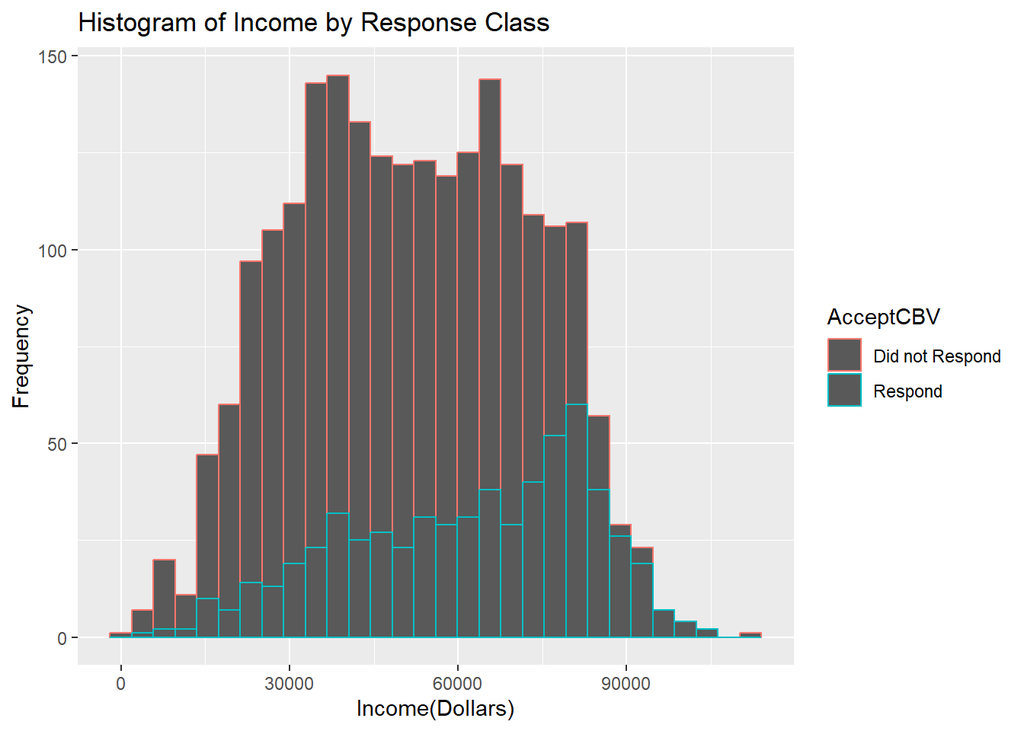

As income increases so does the ratio of people who responded with those who didn’t. I want to know at what income does the ratio of favors the people who have responded to the campaign as income increases.

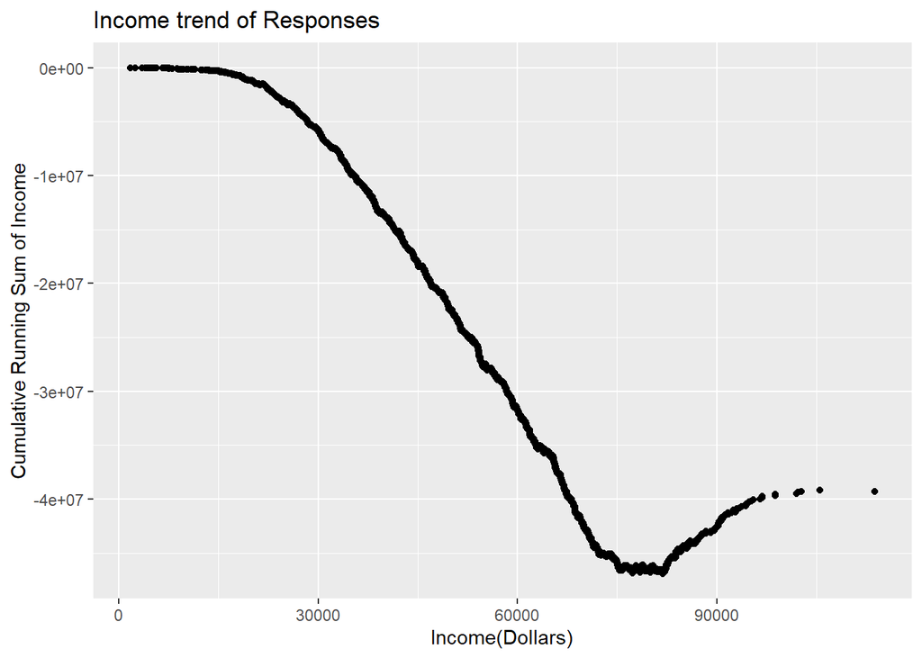

```r
dfEDA$Incomeclass <- ifelse(dfEDA$AcceptBV == 1, dfEDA$Income, dfEDA$Income*-1)
dfEDA<-  dfEDA[order(dfEDA$Income),]
dfEDA$CSIncome <- cumsum(dfEDA$Incomeclass)

ggplot(dfEDA, aes(x = dfEDA$Income,y =dfEDA$CSIncome)) +                        # Try to draw ggplot2 plot
  geom_point()+ ggtitle("Income trend of Responses") +
  xlab("Income(Dollars)") + ylab("Cumulative Running Sum of Income")
```

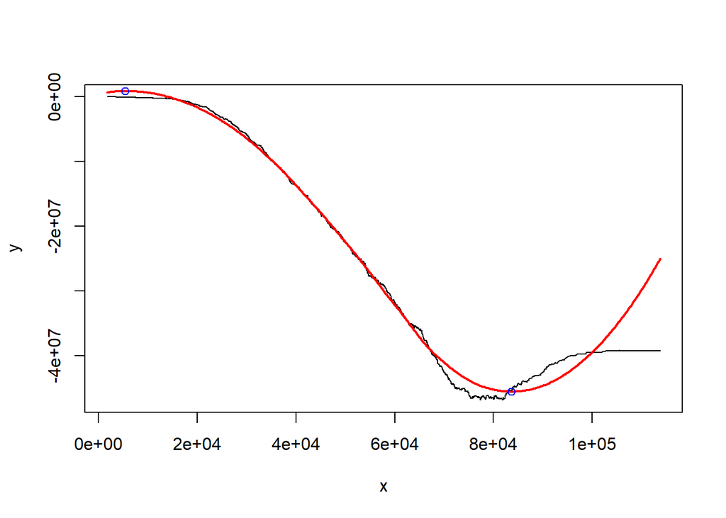

```r
x = dfEDA$Income
y =dfEDA$CSIncome
plot(x,y,type="l")
lo <- loess(y~x)
xl <- seq(min(x),max(x), (max(x) - min(x))/444)
out = predict(lo,xl)
lines(xl, out, col='red', lwd=2)

infl <- c(FALSE, diff(diff(out)>0)!=0)

points(xl[infl ], out[infl ], col="blue")
```

```r
xl[infl]
```

```
## [1]  5513.919 83714.910
```

After about 84,000 dollars the cumulative sum of income starts trend towards customers that accepted the campaign.

The goal should be to get this shift in trend to happen earlier.

Need to make campaign attractive to people making a lower income.

Maybe it is attractive and they can’t afford it. Who knows, but lets try.

Lets look at the campaign acceptances more closely.

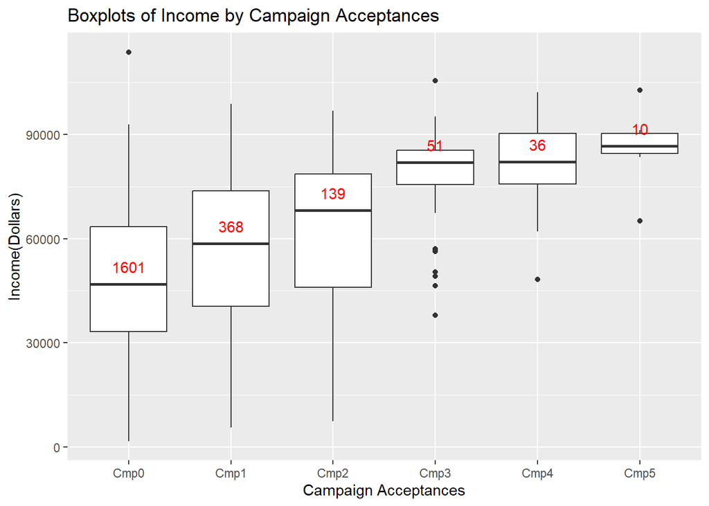

The more times a customer accepts the campaign, the higher the income of the customer.

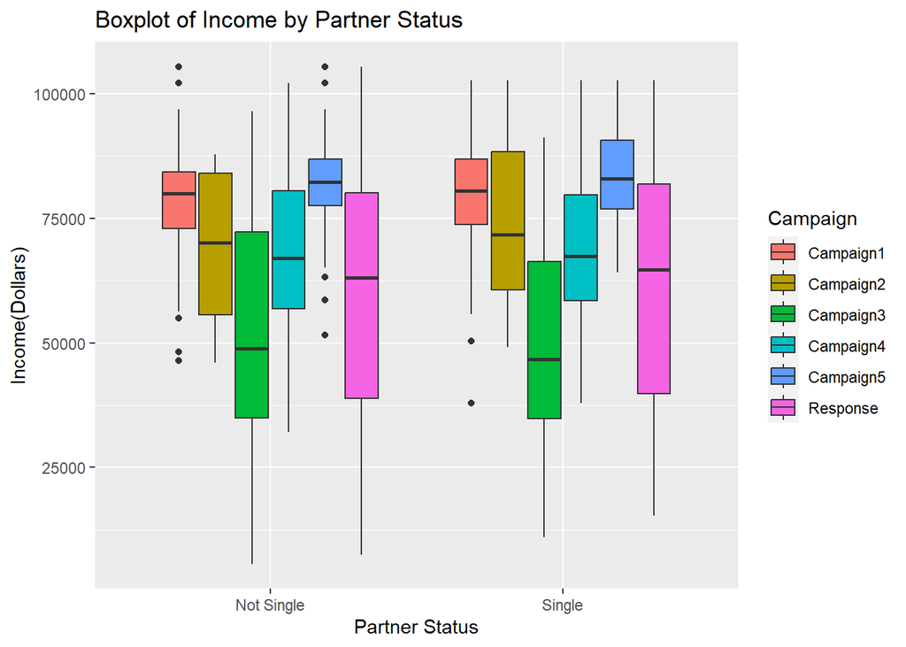

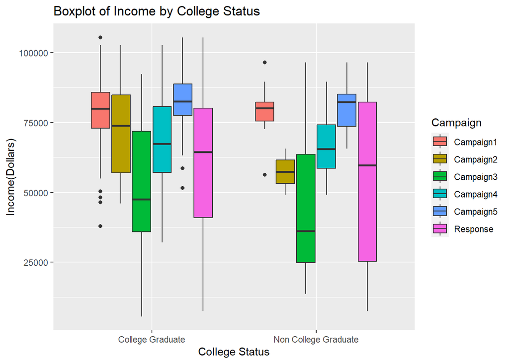

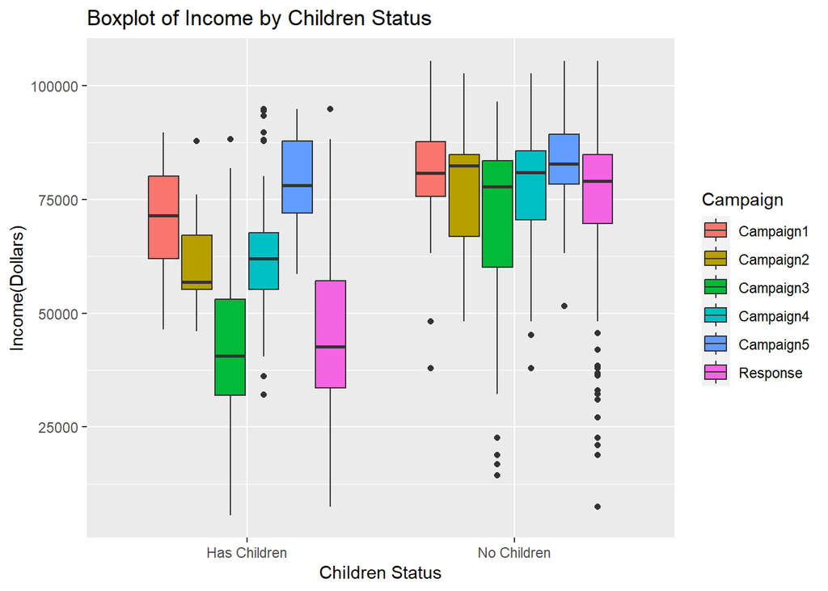

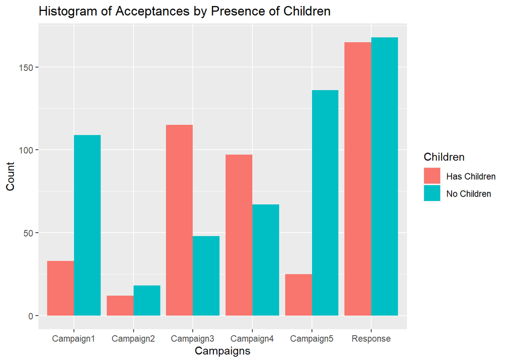

Campaigns 1 and 5 drew in a higher ratio of responses from people without children. Response campaign was well balanced. Campaigns 3 and 4 drew in a higher ratio of response from people with children but at a smaller ratio than Campaigns 1 and 5.

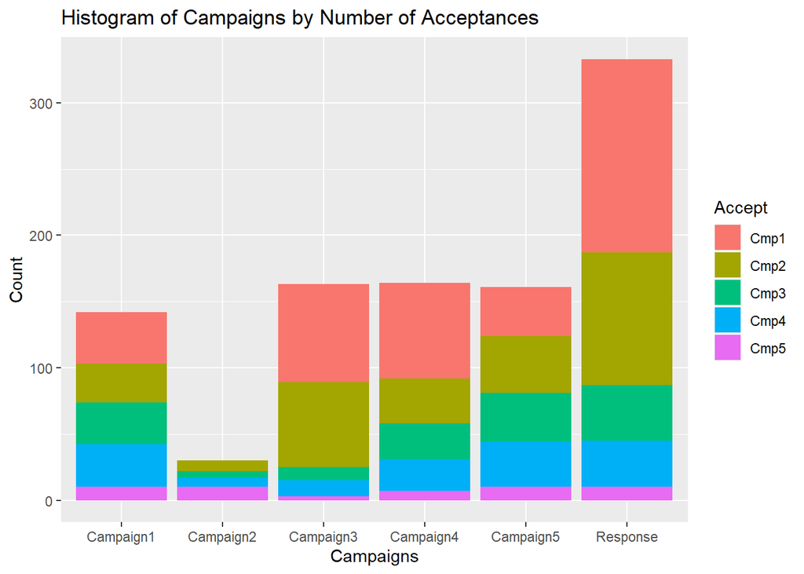

Things to note:

The latest campaign managed to generate a significant response from new customers and customers who have only responded once in the previous 5 campaigns.

No new response to the 2nd campaign.

| **Characteristic** | **Campaign1**, N = 142<sup>1</sup> | **Campaign2**, N = 30<sup>1</sup> | **Campaign3**, N = 163<sup>1</sup> | **Campaign4**, N = 164<sup>1</sup> | **Campaign5**, N = 161<sup>1</sup> | **Response**, N = 333<sup>1</sup> |
| --- | --- | --- | --- | --- | --- | --- |
| Income | 78,872.63 (11,337.02) | 71,054.83 (16,069.84) | 50,802.58 (22,012.66) | 68,663.23 (15,478.93) | 82,345.50 (8,800.56) | 60,209.68 (23,194.08) |
| Recency | 46.68 (28.47) | 48.67 (31.61) | 45.70 (28.51) | 50.81 (29.28) | 49.04 (29.34) | 35.26 (27.62) |
| MntWines | 758.03 (335.81) | 898.67 (467.49) | 378.66 (396.50) | 750.23 (379.36) | 874.50 (333.23) | 502.62 (427.82) |
| NumWebVisitsMonth | 3.51 (2.04) | 5.17 (2.29) | 5.85 (2.53) | 5.07 (2.25) | 2.93 (1.83) | 5.31 (2.56) |
| Age | 51.62 (13.52) | 51.87 (11.09) | 48.55 (12.04) | 53.98 (11.42) | 50.29 (13.84) | 50.50 (12.33) |
| Customer_Days | 2,481.69 (201.43) | 2,523.10 (205.68) | 2,507.02 (211.13) | 2,523.95 (207.15) | 2,509.43 (197.44) | 2,607.08 (196.47) |
| MntTotal | 1,406.70 (501.92) | 1,241.27 (547.81) | 653.60 (663.95) | 1,089.20 (580.74) | 1,538.45 (415.67) | 924.41 (698.91) |
| TOT_Purchase | 19.90 (4.52) | 18.23 (5.83) | 13.26 (8.06) | 17.63 (4.60) | 19.80 (4.30) | 15.35 (6.83) |
| ChildrenBV | 33 / 142 (23%) | 12 / 30 (40%) | 115 / 163 (71%) | 97 / 164 (59%) | 25 / 161 (16%) | 165 / 333 (50%) |
| SingleBV | 48 / 142 (34%) | 11 / 30 (37%) | 63 / 163 (39%) | 60 / 164 (37%) | 52 / 161 (32%) | 175 / 333 (53%) |
| Marital_Status |  |  |  |  |  |  |
| Divorced | 12 / 142 (8.5%) | 5 / 30 (17%) | 20 / 163 (12%) | 18 / 164 (11%) | 13 / 161 (8.1%) | 48 / 333 (14%) |
| Married | 62 / 142 (44%) | 7 / 30 (23%) | 63 / 163 (39%) | 62 / 164 (38%) | 66 / 161 (41%) | 98 / 333 (29%) |
| Single | 31 / 142 (22%) | 5 / 30 (17%) | 39 / 163 (24%) | 32 / 164 (20%) | 32 / 161 (20%) | 109 / 333 (33%) |
| Together | 32 / 142 (23%) | 12 / 30 (40%) | 37 / 163 (23%) | 42 / 164 (26%) | 43 / 161 (27%) | 60 / 333 (18%) |
| Widow | 5 / 142 (3.5%) | 1 / 30 (3.3%) | 4 / 163 (2.5%) | 10 / 164 (6.1%) | 7 / 161 (4.3%) | 18 / 333 (5.4%) |
| CollegeBV | 128 / 142 (90%) | 28 / 30 (93%) | 142 / 163 (87%) | 155 / 164 (95%) | 151 / 161 (94%) | 309 / 333 (93%) |
| Education_Level |  |  |  |  |  |  |
| Basic | 0 / 142 (0%) | 0 / 30 (0%) | 6 / 163 (3.7%) | 0 / 164 (0%) | 0 / 161 (0%) | 2 / 333 (0.6%) |
| Masters | 18 / 142 (13%) | 2 / 30 (6.7%) | 24 / 163 (15%) | 31 / 164 (19%) | 27 / 161 (17%) | 56 / 333 (17%) |
| Phd | 30 / 142 (21%) | 10 / 30 (33%) | 40 / 163 (25%) | 45 / 164 (27%) | 38 / 161 (24%) | 101 / 333 (30%) |
| Second Cycle | 14 / 142 (9.9%) | 2 / 30 (6.7%) | 15 / 163 (9.2%) | 9 / 164 (5.5%) | 10 / 161 (6.2%) | 22 / 333 (6.6%) |
| Undergrad | 80 / 142 (56%) | 16 / 30 (53%) | 78 / 163 (48%) | 79 / 164 (48%) | 86 / 161 (53%) | 152 / 333 (46%) |
| Accept |  |  |  |  |  |  |
| Cmp1 | 39 / 142 (27%) | 0 / 30 (0%) | 74 / 163 (45%) | 72 / 164 (44%) | 37 / 161 (23%) | 146 / 333 (44%) |
| Cmp2 | 29 / 142 (20%) | 8 / 30 (27%) | 64 / 163 (39%) | 34 / 164 (21%) | 43 / 161 (27%) | 100 / 333 (30%) |
| Cmp3 | 32 / 142 (23%) | 5 / 30 (17%) | 10 / 163 (6.1%) | 27 / 164 (16%) | 37 / 161 (23%) | 42 / 333 (13%) |
| Cmp4 | 32 / 142 (23%) | 7 / 30 (23%) | 12 / 163 (7.4%) | 24 / 164 (15%) | 34 / 161 (21%) | 35 / 333 (11%) |
| Cmp5 | 10 / 142 (7.0%) | 10 / 30 (33%) | 3 / 163 (1.8%) | 7 / 164 (4.3%) | 10 / 161 (6.2%) | 10 / 333 (3.0%) |
| AcceptBV | 142 / 142 (100%) | 30 / 30 (100%) | 163 / 163 (100%) | 164 / 164 (100%) | 161 / 161 (100%) | 333 / 333 (100%) |
| TOT_Prods | 1,484.35 (509.56) | 1,307.67 (555.42) | 720.54 (696.27) | 1,137.56 (597.45) | 1,614.96 (420.62) | 985.66 (719.39) |
| TOT_Grocery | 1,406.70 (501.92) | 1,241.27 (547.81) | 653.60 (663.95) | 1,089.20 (580.74) | 1,538.45 (415.67) | 924.41 (698.91) |

<sup>1</sup> Mean (SD); n / N (%)

Notable Occurrences/Observations:

Campaign 3 and the latest campaign show similarities in the customers that responded. Low income, low wine consumption, and overall lower purchase totals.

The percentage of people who graduated college is consistently high at 87%-95%.

Campaigns 1 and 5 seem to have targeted similar high income customers. Campaigns 3 and the response campaign targets a variety of mixed income customers. Campaigns 2 and 4 had an upper income response as well but not as high income as campaigns 1 and 5. *Campaign 2 is less than a third of all other campaigns*

### 2.3.2 Wines

Wines

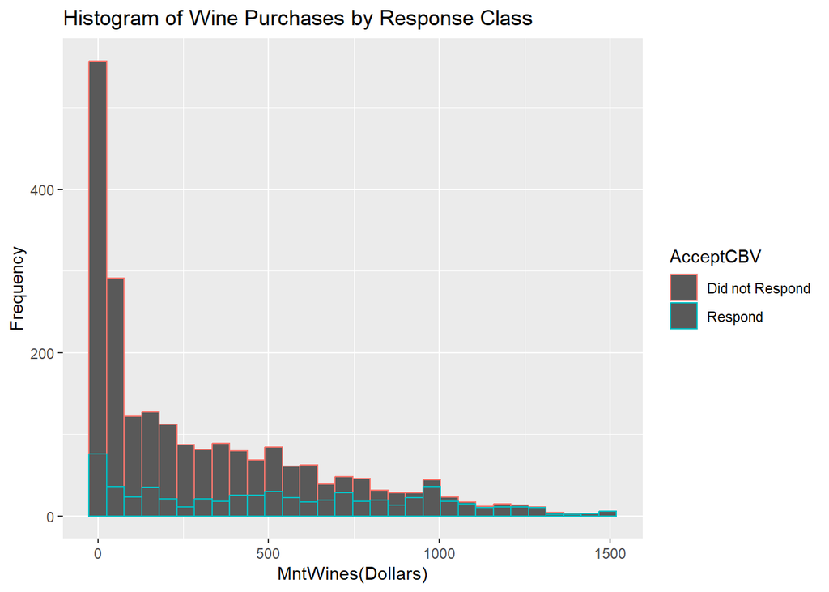

# 3 Modeling Segmentations

## 3.1 Using K mean clustering

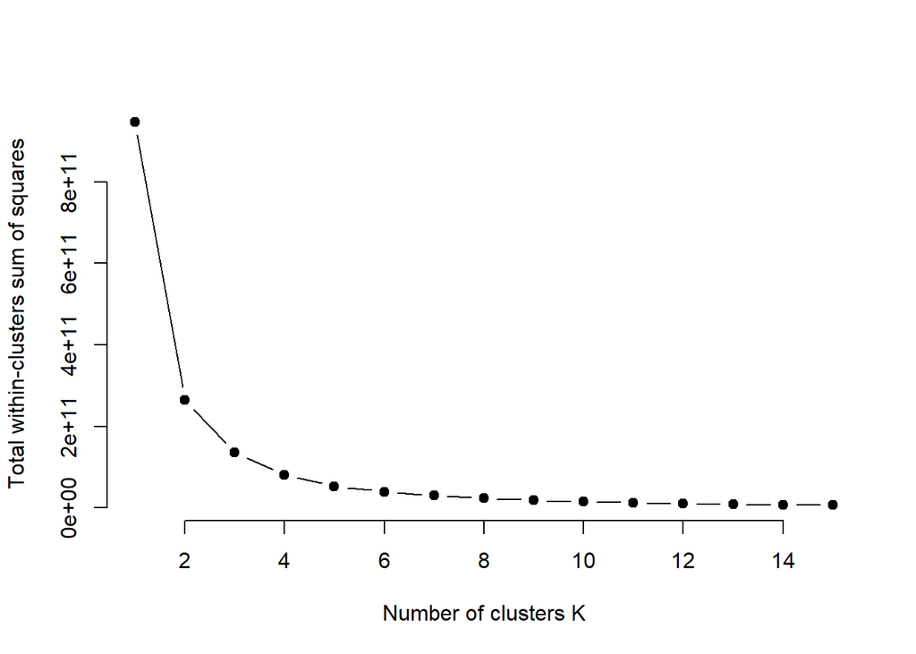

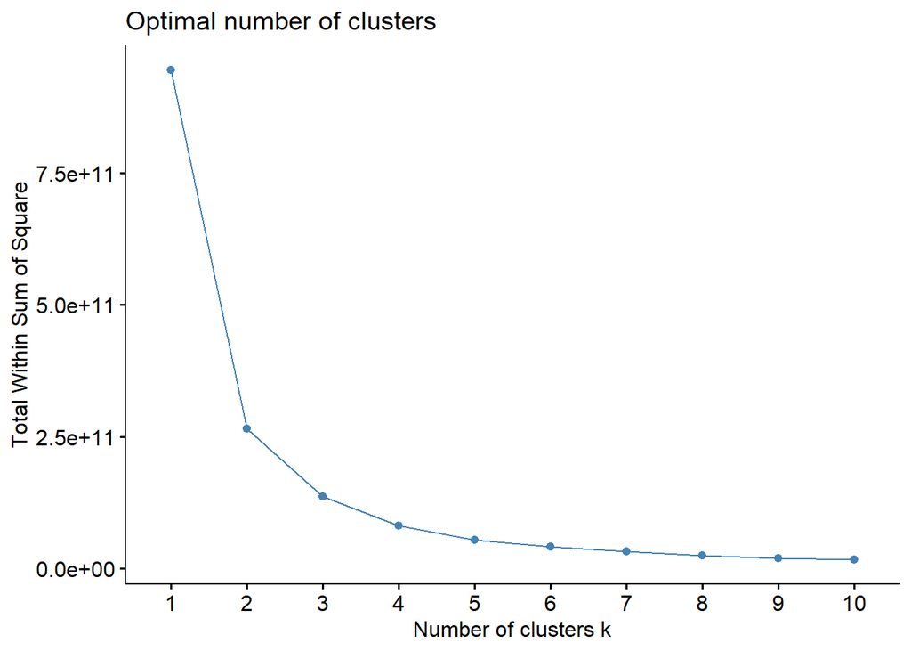

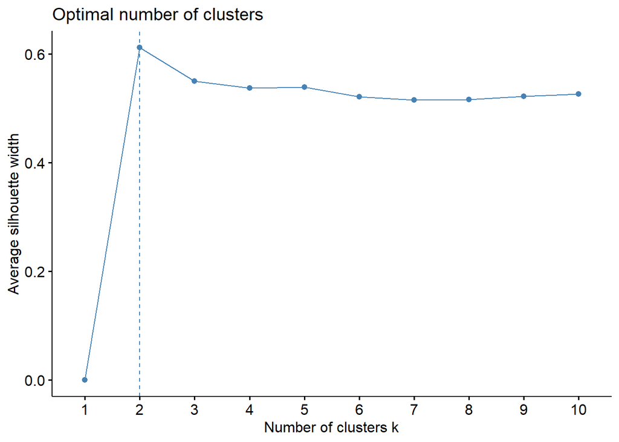

[output not shown]

[output cut: 62 more lines]

With a sum of squares by cluster of .72, this is a goo clustering solution for these particular indicators in the data set.

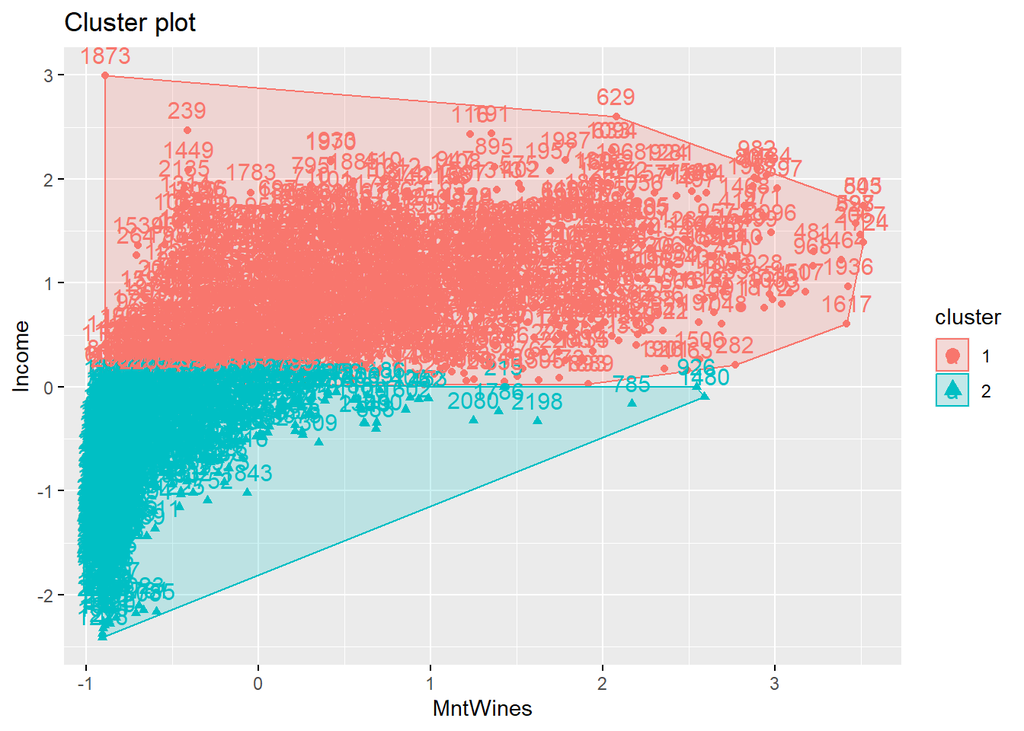

# 4 Predictive Model

## 4.1 LASSO

### 4.1.1 Training Model

```r
set.seed(123)

training.samples <- dfmodel$Response %>%
  createDataPartition(p = 0.8, list = FALSE)

train.data  <- dfmodel[training.samples, ]
test.data <- dfmodel[-training.samples, ]
```

### 4.1.2 LASSO model with reduced KPIs

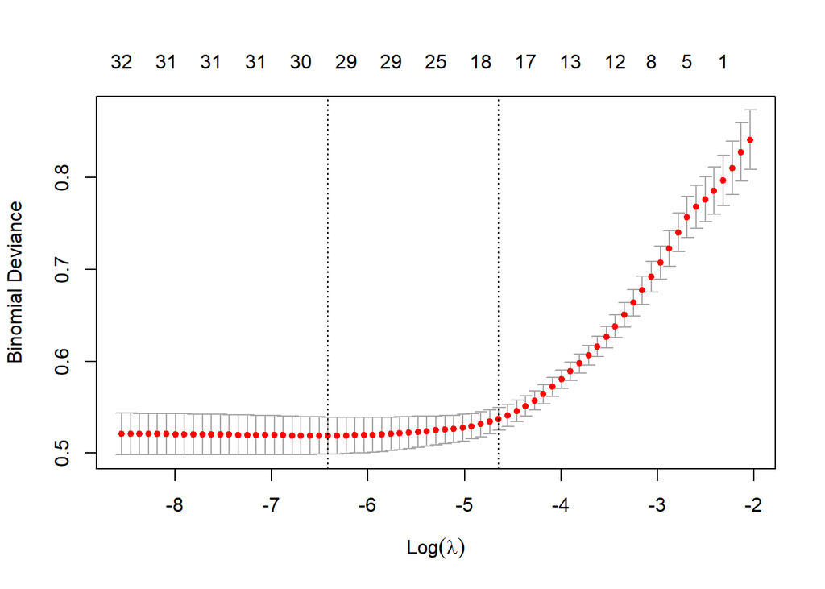

```r
x <- model.matrix(Response~., train.data)[,-22]
# Convert the outcome (class) to a numerical variable
y <- ifelse(train.data$Response == 1, 1, 0)

# Find the best lambda using cross-validation
set.seed(123)
cv.lasso <- cv.glmnet(x, y, alpha = 1, family = "binomial")
plot(cv.lasso)
```

### 4.1.3 LASSO model predictions

```r
# Fit the final model on the training data
model <- glmnet(x, y, alpha = 1, family = "binomial",
                lambda = cv.lasso$lambda.min)
# Display regression coefficients
coef(model)
```

```
## 43 x 1 sparse Matrix of class "dgCMatrix"
##                                 s0
## (Intercept)          -1.338483e+01
## (Intercept)           .
## Income                .
## Kidhome               2.541566e-01
## Teenhome             -8.944843e-01
## Recency              -3.063529e-02
## MntWines             -7.711868e-04
## MntFruits             2.721773e-03
## MntMeatProducts       2.371779e-03
## MntFishProducts      -2.282393e-03
## MntSweetProducts      .
## MntGoldProds          1.838066e-03
## NumDealsPurchases     1.644908e-01
## NumWebPurchases       6.105248e-02
## NumCatalogPurchases   1.624755e-01
## NumStorePurchases    -2.042529e-01
## NumWebVisitsMonth     7.581466e-02
## AcceptedCmp3          1.436130e+00
## AcceptedCmp4          9.776652e-01
## AcceptedCmp5          1.494024e+00
## AcceptedCmp1          1.049988e+00
## AcceptedCmp2          1.761545e+00
## Age                   6.702086e-03
## Customer_Days         4.175057e-03
## marital_Divorced      5.122041e-02
## marital_Married       .
## marital_Single        .
## marital_Together      .
## marital_Widow        -1.668337e-01
## education_2n_Cycle    .
## education_Basic      -9.599181e-01
## education_Graduation  .
## education_Master      4.117749e-01
## education_PhD         1.187721e+00
## MntTotal              .
## TOT_Purchase          .
## TOT_Children          .
## ChildrenBV           -2.648628e-01
## SingleBV              1.160085e+00
## CollegeBV             5.142897e-02
## Accept5BV             5.759373e-01
## TOT_Prods             .
## TOT_Grocery           .
```

```r
# Make predictions on the test data
x.test <- model.matrix(Response ~., test.data)[,-22]
probabilities <- model %>% predict(newx = x.test)
predicted.classes <- ifelse(probabilities > 0.5, 1, 0)
# Model accuracy
observed.classes <- test.data$Response

mean(predicted.classes == observed.classes)
```

```
## [1] 0.8956916
```

### 4.1.4 Logistic model with all indicators

```r
# Fit the model
full.model <- glm(Response ~., data = train.data, family = binomial)
# Make predictions
probabilities <- full.model %>% predict(test.data[,-22], type = "response")
predicted.classes <- ifelse(probabilities > 0.5, 1, 0)
# Model accuracy
observed.classes <- test.data$Response
mean(predicted.classes == observed.classes)
```

```
## [1] 0.893424
```

### 4.1.5 Results of LASSO model

Not only does the LASSO model use 12 fewer indicators than the full Logistic model, it also predicts a higher rate of the observations.